# Homework 5

Luke Todd

2023-06-05

# Introduction

Sarracenia are a group of carnivorous plants mainly found in North America, specifically in “wet savannas, seepage slopes, and bog environments” (Sexton). Their pitcher-shaped leaves allow them to capture and digest insects, allowing Sarracenia to uptake nutrients despite their often lacking ecosystems. Scientists are often very interested in them because of their ability to use their unique shape, design, and digestive enzymes to trap and digest insects, all without having any moving parts (Takeuchi). The health of Sarracenia are important because they contribute to the biodiversity of these nutrient-depleted ecosystems. Recently, studies following the “community assembly and structure [of these] carnivorous pitcher plants has increased dramatically” (Heil). By studying how biomass is affected by morphological, physiological, or taxonomic characteristics, we are able to measure the health of these Sarracenia and see what factors might contribute to a larger plant. Thus, we can see what characteristics are important when guiding conservation efforts, or when studying the health of ecosystems. In this study, we are addressing the question of, “what characteristics are most related to the total biomass of a Sarracenia?” I hypothesize that species, feedlevel, and num_lvs will be the most significant predictors of total biomass.

# Methods

### Loading Data

```r
sar <- read.csv(here("Data/hf109-01-sarracenia.csv")) %>%
  clean_names() %>%
  select(totmass, species, feedlevel, sla, chlorophyll, amass, num_lvs, num_phylls)
```

### Sampling Methods

In this study, two plants of each Sarracenia species were selected, each with varying size. There were 120 plants total, and each other them were assigned to one of six feeding levels. Feeding would occur once a week for 7 weeks. (Ellison, Farnsworth).

### Data Organization

The collected data is implemented into a dataset, where each column was a variable, and each row was an observation about the variable.

### Missing Data Visualization

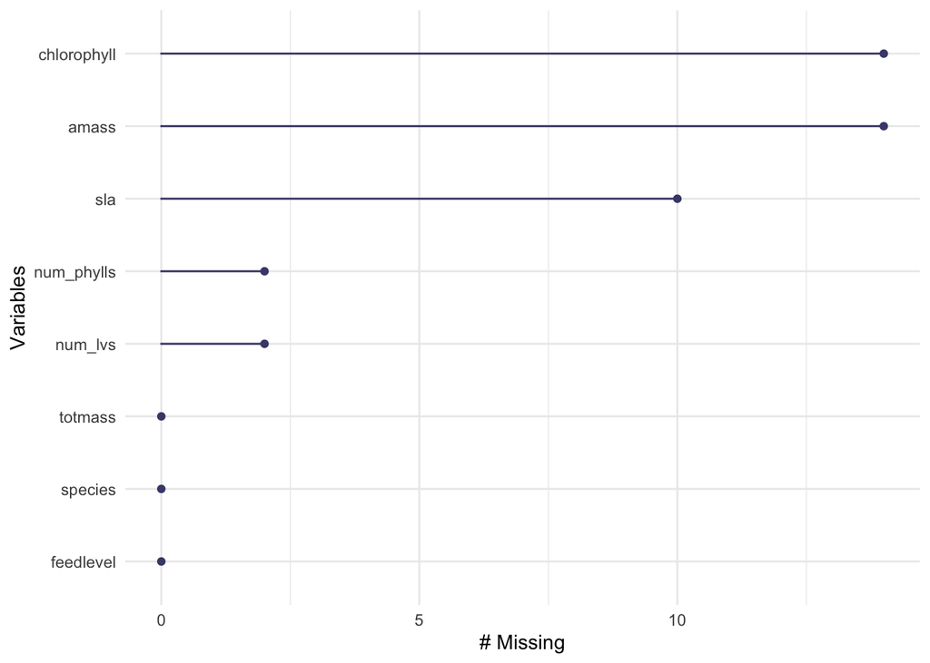

This figure displays the number of missing values for each variable in the sar data frame. Based on this figure, we can see that chlorophyll (Chlorophyll content), amass (Photosynthetic Rate), and sla (Specific Leaf Area) are missing the most values with 14, 14, and 10 missing values, respectively. Num_phylls and num_lvs are missing 2 values, and the rest are missing none.

```r
gg_miss_var(sar)
```

```r
# creating a dataset without the missing values
sar_nona <- sar %>%
  drop_na(sla, chlorophyll, amass, num_lvs, num_phylls)
```

### Pearson’s Correlation Visualization

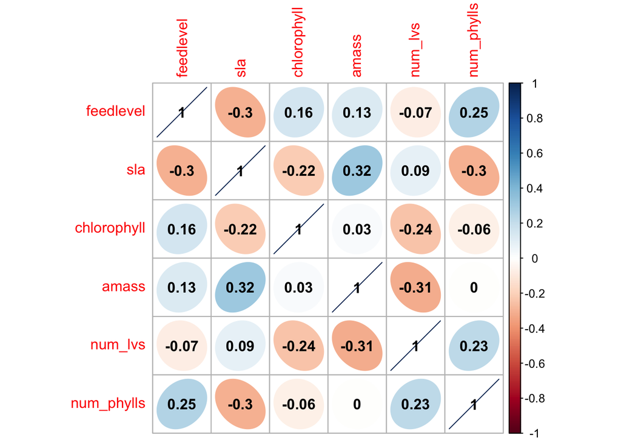

This figure displays the Person’s correlation values between different variables. High absolute values means that there is a greater correlation between the variables. For example, sla and amass have the greatest positive correlation between each other with a value of 0.32. On the otherhand, num_lvs and amass have the greatest negative correlation between each other with a value of -0.31.

```r
# calc Pearson's r for numerical values
sar_cor <- sar_nona %>%
  select(feedlevel:num_phylls) %>%
  cor(method = "pearson")

# plot correlation values
corrplot(sar_cor,
         method = "ellipse",
         addCoef.col = "black")
```

### Variable Relationships

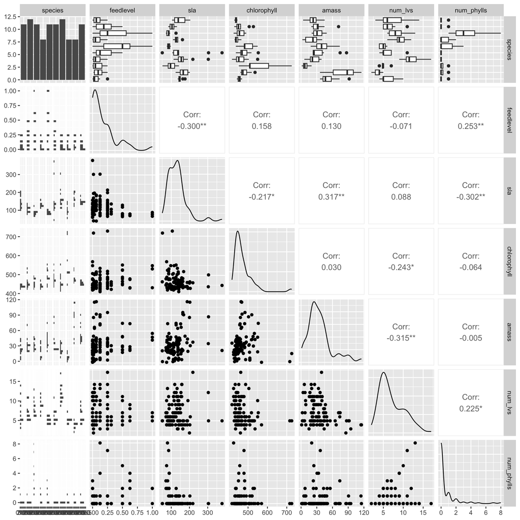

```r
sar_nona %>%
  select(species:num_phylls) %>%
  ggpairs()
```

### Null and Full Models

As we are trying to predict totmass, the y-value is set to totmass. For the null model, we set the x-value to 1, as this selects for just the intercept. For the full model, we select every variable that we are interested in.

```r
null <- lm(totmass ~ 1, data = sar_nona)
full <- lm(totmass ~ species + feedlevel +
             sla + chlorophyll + amass +
             num_lvs + num_phylls,
           data = sar_nona)
```

### Diagnostic Checks

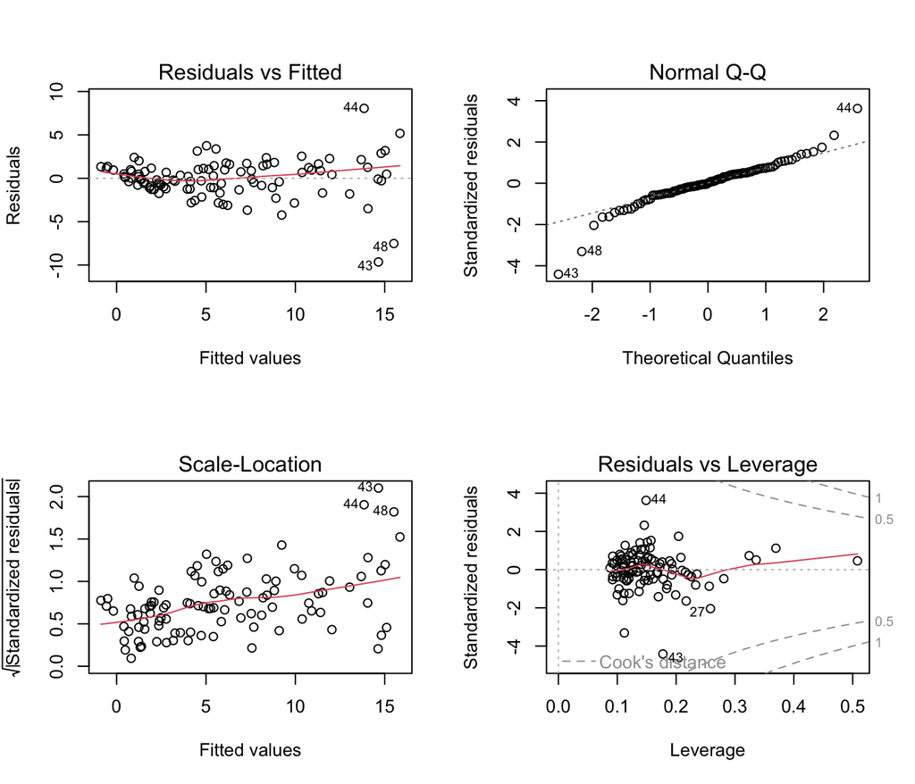

```r
# visual diagnostics for full model
par(mfrow = c(2, 2))
plot(full)
```

```r
# statistical diagnostic checks
check_normality(full)
check_heteroscedasticity(full)
```

Checking normality and homoscedasticity assumptions both gave p-values less than 0.001, indicating that our current full model is non-normal and heteroscedastic. Because of this, we will log-transform our model and retest the diagnostics.

```r
# creating log transformed models
null_log <- lm(log(totmass) ~ 1, data = sar_nona)
full_log <- lm(log(totmass) ~ species + feedlevel +
                 sla + chlorophyll + amass + num_lvs +
                 num_phylls,
               data = sar_nona)
```

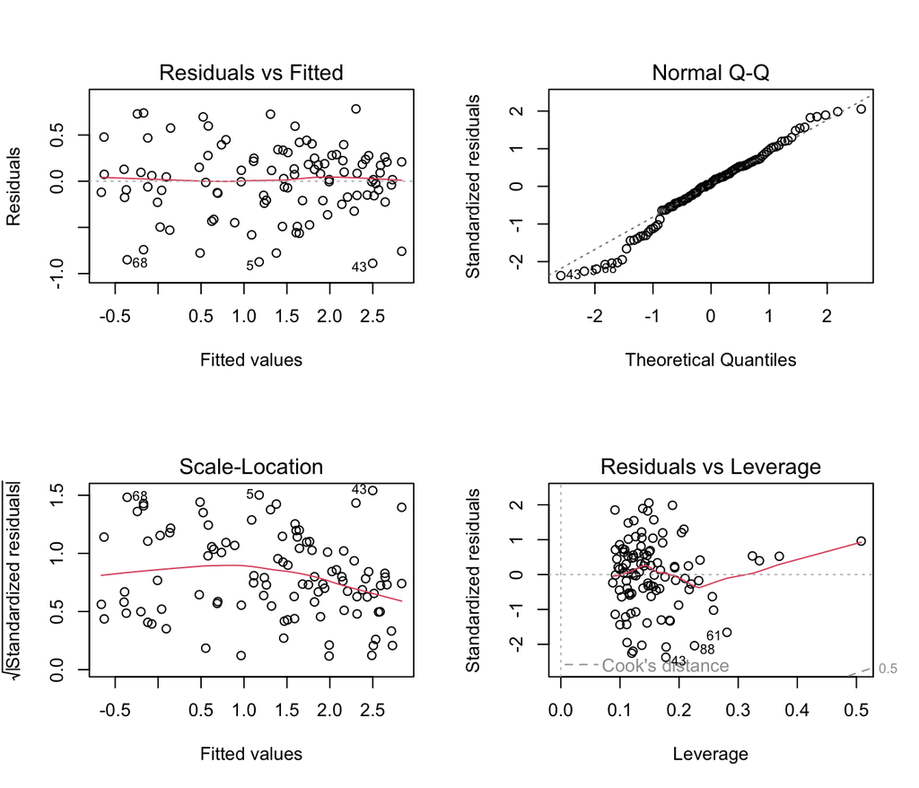

```r
# visual diagnostic checks
par(mfrow = c(2, 2))
plot(full_log)
```

```r
# statistical diagnostic checks
check_normality(full_log)
```

```
## OK: residuals appear as normally distributed (p = 0.107).
```

```r
check_heteroscedasticity(full_log)
```

```
## OK: Error variance appears to be homoscedastic (p = 0.071).
```

The statistical diagnostic checks for normality and homoscedasticity passed, so we will continue using the log-transformed model.

### Model Construction

```r
# using ANOVA tables to create new models, eliminating one non-significant variable at a time
anova(full_log)
```

```
## Analysis of Variance Table
##
## Response: log(totmass)
##             Df Sum Sq Mean Sq F value    Pr(>F)
## species      9 91.175 10.1305 59.3944 < 2.2e-16 ***
## feedlevel    1  0.110  0.1099  0.6442 0.4243716
## sla          1  1.300  1.3003  7.6236 0.0070259 **
## chlorophyll  1  2.564  2.5636 15.0301 0.0002049 ***
## amass        1  0.033  0.0330  0.1937 0.6609205
## num_lvs      1  2.921  2.9205 17.1227 8.068e-05 ***
## num_phylls   1  0.100  0.0999  0.5859 0.4460675
## Residuals   87 14.839  0.1706
## ---
## Signif. codes:  0 '***' 0.001 '**' 0.01 '*' 0.05 '.' 0.1 ' ' 1
```

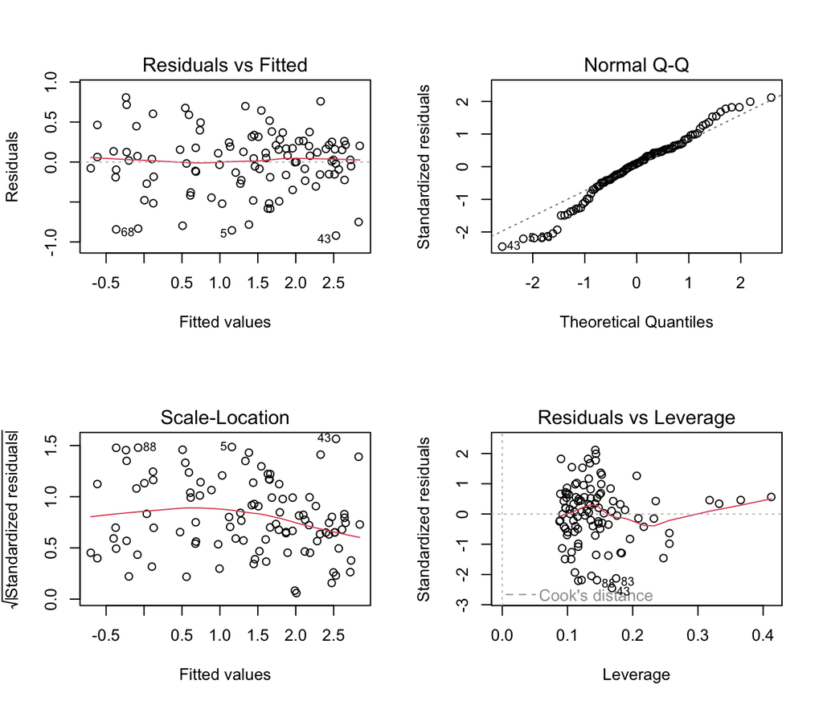

```r
# based on this ANOVA, I will create a model without "amass" since it had the highest p-value
model2 <- lm(log(totmass) ~ species + feedlevel + sla + chlorophyll + num_lvs + num_phylls,
             data = sar_nona)

# checking model2 visual diagnostics
par(mfrow = c(2, 2))
plot(model2)
```

```r
# checking model statistical diagnostics
check_normality(model2)
```

```
## OK: residuals appear as normally distributed (p = 0.075).
```

```r
check_heteroscedasticity(model2)
```

```
## OK: Error variance appears to be homoscedastic (p = 0.054).
```

Based on the visual and statistical diagnostic test, model2 passes all tests. Next, I will eliminate another variable and see if it still passes these tests.

```r
anova(model2)
```

```
## Analysis of Variance Table
##
## Response: log(totmass)
##             Df Sum Sq Mean Sq F value    Pr(>F)
## species      9 91.175 10.1305 59.6575 < 2.2e-16 ***
## feedlevel    1  0.110  0.1099  0.6471 0.4233265
## sla          1  1.300  1.3003  7.6574 0.0068914 **
## chlorophyll  1  2.564  2.5636 15.0966 0.0001975 ***
## num_lvs      1  2.866  2.8665 16.8803 8.903e-05 ***
## num_phylls   1  0.083  0.0827  0.4868 0.4872174
## Residuals   88 14.943  0.1698
## ---
## Signif. codes:  0 '***' 0.001 '**' 0.01 '*' 0.05 '.' 0.1 ' ' 1
```

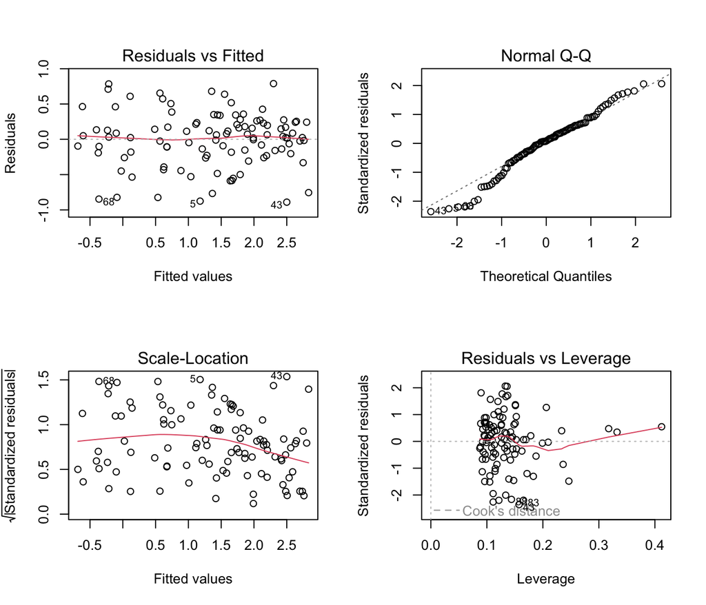

```r
# based on the above ANOVA, I will create a model without "num_phylls" since it had the highest p-value
model3 <- lm(log(totmass) ~ species + feedlevel + sla + chlorophyll + num_lvs,
             data = sar_nona)

# checking model2 visual diagnostics
par(mfrow = c(2, 2))
plot(model3)
```

```r
# checking model statistical diagnostics
check_normality(model3)
```

```
## OK: residuals appear as normally distributed (p = 0.062).
```

```r
check_heteroscedasticity(model3)
```

```
## OK: Error variance appears to be homoscedastic (p = 0.067).
```

Based on the visual and statistical diagnostic test, model3 passes all tests. Next, I will eliminate another variable and see if it still passes these tests.

```r
anova(model3)
```

```
## Analysis of Variance Table
##
## Response: log(totmass)
##             Df Sum Sq Mean Sq F value    Pr(>F)
## species      9 91.175 10.1305 60.0035 < 2.2e-16 ***
## feedlevel    1  0.110  0.1099  0.6508 0.4219656
## sla          1  1.300  1.3003  7.7018 0.0067230 **
## chlorophyll  1  2.564  2.5636 15.1842 0.0001885 ***
## num_lvs      1  2.866  2.8665 16.9782 8.457e-05 ***
## Residuals   89 15.026  0.1688
## ---
## Signif. codes:  0 '***' 0.001 '**' 0.01 '*' 0.05 '.' 0.1 ' ' 1
```

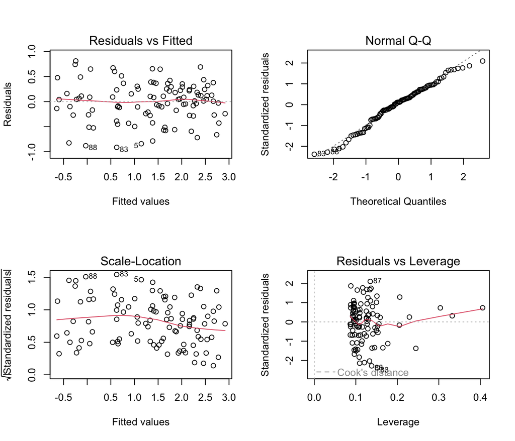

```r
# based on the above ANOVA, I will create a model without "feedlevel" since it had the highest p-value
model4 <- lm(log(totmass) ~ species + sla + chlorophyll + num_lvs,
             data = sar_nona)

# checking model2 visual diagnostics
par(mfrow = c(2, 2))
plot(model4)
```

```r
# checking model statistical diagnostics
check_normality(model4)
```

```
## OK: residuals appear as normally distributed (p = 0.169).
```

```r
check_heteroscedasticity(model4)
```

The statistical tests show that model4 appears to have heteroscedasticity, or non-constant error variance, with a p-value of 0.036.

The type of model selection that I used above is called backward model selection. It begins at a full model and you slowly eliminate the least significant variable, until you are left with a model that passes all diagnostics, but has the least amount of predictor variables. Most of the time, it is better to have the least amount of predictor variables as possible since it increases the interpretability of your model. Based on the above method, “model3” appears to be our best model.

### Variance Inflation Factor

```r
# full model variance inflation factor check
car::vif(full_log)
```

```
##                  GVIF Df GVIF^(1/(2*Df))
## species     42.351675  9        1.231351
## feedlevel    1.621993  1        1.273575
## sla          1.999989  1        1.414210
## chlorophyll  1.949828  1        1.396362
## amass        2.872084  1        1.694722
## num_lvs      2.813855  1        1.677455
## num_phylls   2.995510  1        1.730754
```

Based on the results, we can see that every variable has a GVIF value greater than 1, indicating that there is some multicollinearity. Ideally, you want to be as close as possible to 1.

### Model Comparison

```r
# comparing models using AIC
MuMIn::AICc(full, full_log, null, model2, model3, model4)
```

```
##          df     AICc
## full     17 497.3964
## full_log 17 133.9424
## null      2 630.4028
## model2   16 131.7899
## model3   15 129.5498
## model4   14 130.8121
```

The above chart shows that model3 has the lowest AICc value. Therefore, we will choose model3 as the best model.

# Results

### Model Selection

The best model was model3, which used the variables species, feedlevel, sla, chlorophyll, and num_lvs to predict log(totmass). I chose this model by using backward model selection, starting from the full model, and slowly eliminating unnecessary, insignificant variables. Model3 was the smallest model that passed the model diagnostics, and it also had the lowest AICc.

| Model | Formula | AICc | Diagnostic P/NP |
| --- | --- | --- | --- |
| full | totmass ~ species + feedlevel + sla + chlorphyll + amass + num_lvs + num_phylls | 497.3964 | NP |
| full_log | log(totmass) ~ species + feedlevel + sla + chlorphyll + amass + num_lvs + num_phylls | 133.9424 | P |
| null | totmass ~ 1 | 630.4028 | NA |
| model2 | log(totmass) ~ species + feedlevel + sla + chlorophyll + num_lvs + num_phylls | 131.7899 | P |
| model3 | log(totmass) ~ species + feedlevel + sla + chlorophyll + num_lvs | 129.5498 | P |
| model4 | log(totmass) ~ species + sla + chlorophyll + num_lvs | 130.8121 | NP |

```r
# summary of model3
summary(model3)
```

```
##
## Call:
## lm(formula = log(totmass) ~ species + feedlevel + sla + chlorophyll +
##     num_lvs, data = sar_nona)
##
## Residuals:
##      Min       1Q   Median       3Q      Max
## -0.89025 -0.19762  0.03105  0.23873  0.78907
##
## Coefficients:
##                     Estimate Std. Error t value Pr(>|t|)
## (Intercept)        -1.391293   0.585389  -2.377 0.019611 *
## speciesalata        1.137098   0.179533   6.334 9.53e-09 ***
## speciesflava        1.303336   0.196108   6.646 2.34e-09 ***
## speciesjonesii      0.318323   0.195368   1.629 0.106773
## speciesleucophylla  1.696525   0.212727   7.975 4.89e-12 ***
## speciesminor        0.397390   0.185607   2.141 0.035005 *
## speciespsittacina  -1.613985   0.200970  -8.031 3.75e-12 ***
## speciespurpurea    -0.434552   0.243679  -1.783 0.077947 .
## speciesrosea       -0.866787   0.213093  -4.068 0.000102 ***
## speciesrubra        0.928795   0.177515   5.232 1.10e-06 ***
## feedlevel          -0.430123   0.228916  -1.879 0.063523 .
## sla                -0.002127   0.001063  -2.001 0.048421 *
## chlorophyll         0.004603   0.001154   3.989 0.000136 ***
## num_lvs             0.083852   0.020350   4.120 8.46e-05 ***
## ---
## Signif. codes:  0 '***' 0.001 '**' 0.01 '*' 0.05 '.' 0.1 ' ' 1
##
## Residual standard error: 0.4109 on 89 degrees of freedom
## Multiple R-squared:  0.8671, Adjusted R-squared:  0.8477
## F-statistic: 44.66 on 13 and 89 DF,  p-value: < 2.2e-16
```

```r
# table for model3
table <- tidy(model3, conf.int = TRUE, exponentiate = TRUE) %>%
  # change the p-value numbers if they're really small
  # change the estmaes, standard error, and t-tstatistics to round to ___ digits
  # using mutate
  # make it into a flextable
  flextable() %>%
  # fit it to the viewer
  autofit()

table
```

| term | estimate | std.error | statistic | p.value | conf.low | conf.high |
| --- | --- | --- | --- | --- | --- | --- |
| (Intercept) | 0.2487535 | 0.585388789 | -2.376699 | 0.019611401006898569 | 0.07773513 | 0.7960145 |
| speciesalata | 3.1177086 | 0.179533417 | 6.333630 | 0.000000009533443427 | 2.18227786 | 4.4541105 |
| speciesflava | 3.6815578 | 0.196108146 | 6.646006 | 0.000000002335496696 | 2.49346488 | 5.4357564 |
| speciesjonesii | 1.3748207 | 0.195367931 | 1.629353 | 0.106772894004590987 | 0.93251636 | 2.0269156 |
| speciesleucophylla | 5.4549604 | 0.212726581 | 7.975145 | 0.000000000004885733 | 3.57456029 | 8.3245463 |
| speciesminor | 1.4879363 | 0.185606930 | 2.141031 | 0.035005049074453343 | 1.02900584 | 2.1515471 |
| speciespsittacina | 0.1990927 | 0.200970367 | -8.030959 | 0.000000000003753586 | 0.13354609 | 0.2968106 |
| speciespurpurea | 0.6475548 | 0.243678551 | -1.783299 | 0.077946618166472151 | 0.39902312 | 1.0508846 |
| speciesrosea | 0.4202997 | 0.213092762 | -4.067653 | 0.000102425514875563 | 0.27521626 | 0.6418655 |
| speciesrubra | 2.5314569 | 0.177514843 | 5.232210 | 0.000001103697661969 | 1.77904515 | 3.6020863 |
| feedlevel | 0.6504289 | 0.228915557 | -1.878960 | 0.063522841185113463 | 0.41272508 | 1.0250353 |
| sla | 0.9978755 | 0.001062740 | -2.001167 | 0.048420790786492210 | 0.99577061 | 0.9999849 |
| chlorophyll | 1.0046140 | 0.001153958 | 3.989185 | 0.000135789498714607 | 1.00231313 | 1.0069201 |
| num_lvs | 1.0874684 | 0.020350265 | 4.120456 | 0.000084568149269557 | 1.04437314 | 1.1323419 |

### Model Interpretation

Model3 essentially states that the variables species, feedlevel, sla, chlorophyll, and num_lvs are the best predictors of log(totmass).

### Visualization of Model Predictions

```r
# model prediction of biomass as a function of species

model_pred <- ggpredict(model3, terms = "species", back.transform = TRUE)
```

```
## Model has log-transformed response. Back-transforming predictions to
##   original response scale. Standard errors are still on the log-scale.
```

```
## Model has log-transformed response. Back-transforming predictions to
##   original response scale. Standard errors are still on the log-scale.
```

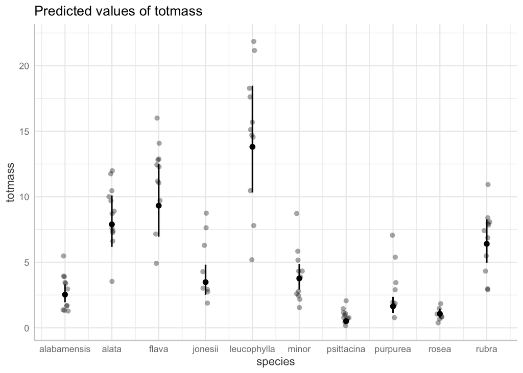

This figure shows the model predictions for biomass as a function of the species predictor. Biomass is predicted to be highest when the species is leucophylla and lowest when the species are psittacina or rosea.

```r
plot(ggpredict(model3, terms = "species", back.transform = TRUE), add.data = TRUE)
```

```
## Model has log-transformed response. Back-transforming predictions to
##   original response scale. Standard errors are still on the log-scale.
```

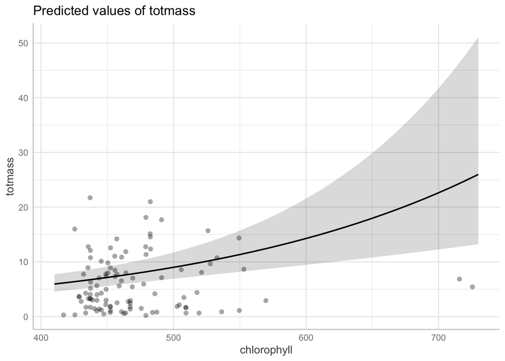

This figure shows the model prediction of biomass as a function of chlorphyll. This predicts that as chlorophyll increases, biomass also increases.

```r
# model prediction of biomass as a function of "chlorophyll"
plot(ggpredict(model3, terms = "chlorophyll", back.transform = TRUE), add.data = TRUE)
```

### Discussion

Biologically, the results of this model tell us that total biomass of a Sarracenia is dependent on what species of Sarracenia it is, how many grams of ground hymenoptera it is fed per week, how much specific leaf area it has, how much chlorophyll a+b content it has, and how many total number of pitchers and phyllodes it produces. In other words, it means that Sarracenia biomass is not predicted by a single measure, but rather by a lot of different variables.

# Bibliography

Sexton, W. K. et al. “Characterization of Endophytic Bacterial Communities Within Greenhouse and Field-Grown Rhizomes of Three Rare Pitcher Plant Species (Sarracenia Oreophila, S. Leucophylla, and S. Purpurea Spp. Venosa) with an Emphasis on Nitrogen-Fixing Bacteria.” Plant and soil 447.1-2 (2020): 257–279. Web.

Takeuchi, Yayoi et al. “Bacterial Diversity and Composition in the Fluid of Pitcher Plants of the Genus Nepenthes.” Systematic and applied microbiology 38.5 (2015): 330–339. Web.

Heil, Jacob A. et al. “Sarracenia Pitcher Plant‐associated Microbial Communities Differ Primarily by Host Species Across a Longitudinal Gradient.” Environmental microbiology 24.8 (2022): 3500–3516. Web.